# mtcars MPG Predictor

July 13, 2026

## The problem

How many **miles per gallon** should you expect from a car, given a few basic specs – its weight, horsepower, cylinders and transmission?

- Buyers and students want a quick, interpretable estimate.
- The classic `mtcars` dataset (32 cars, 1974 *Motor Trend*) is perfect for a small, reproducible model.

The **mtcars MPG Predictor** turns that dataset into an interactive tool: move a few sliders and get an instant, model-based MPG estimate.

## The model (runs when slidified)

The app fits one ordinary least-squares regression on startup. Here it is, evaluated live in this slide deck:

```r
fit <- lm(mpg ~ wt + hp + factor(cyl) + factor(am), data = mtcars)
round(coef(fit), 2)
```

```
##  (Intercept)           wt           hp factor(cyl)6 factor(cyl)8  factor(am)1
##        33.71        -2.50        -0.03        -3.03        -2.16         1.81
```

Interpretation: heavier, higher-horsepower cars lose MPG; a manual transmission (`factor(am)1`) and fewer cylinders tend to add MPG. The model explains a large share of the variation:

```r
paste0("Adjusted R-squared: ", round(summary(fit)$adj.r.squared, 3))
```

```
## [1] "Adjusted R-squared: 0.84"
```

## A worked prediction

A user who dials in a 3,200-lb, 150-hp, 6-cylinder car with a manual gearbox gets this estimate – computed exactly as the Shiny server does:

```r
newcar <- data.frame(wt = 3.2, hp = 150, cyl = 6, am = 1)
round(predict(fit, newcar), 1)
```

```
##    1
## 19.7
```

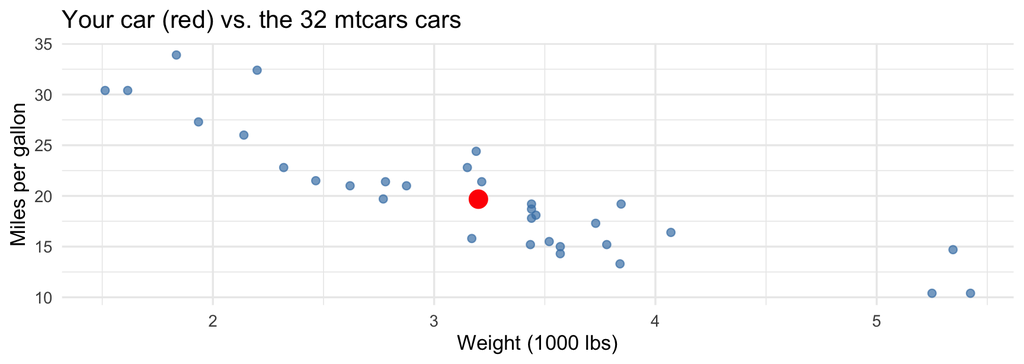

## Using the app

The interface is deliberately simple – no R knowledge required:

1. **Sliders** set weight and horsepower.
2. **Radio buttons** choose cylinders (4 / 6 / 8) and transmission.
3. The predicted **MPG** updates instantly at the top of the page.
4. A **Plotly** chart marks your car in red against the real data.

Every screen has built-in help, and a **Documentation** tab explains the model in plain language. Inputs flow through a `reactive()` expression in `server.R`, so output refreshes with no button press.

## Why it’s useful

- **Reproducible:** one dataset, one transparent linear model, all in ~90 lines of `ui.R` + `server.R`.
- **Interactive & instant:** reactive prediction and an interactive Plotly plot.
- **Self-documenting:** novice users get started with no prerequisites.
- **Extensible:** swap in another dataset or add predictors in a few lines.

> Try it, move the sliders, and see how weight and horsepower trade off against fuel economy.

Thank you!